# Bellabeat: A Case Study (Leaf Tracker)

# Extended Analysis Through Visualizations

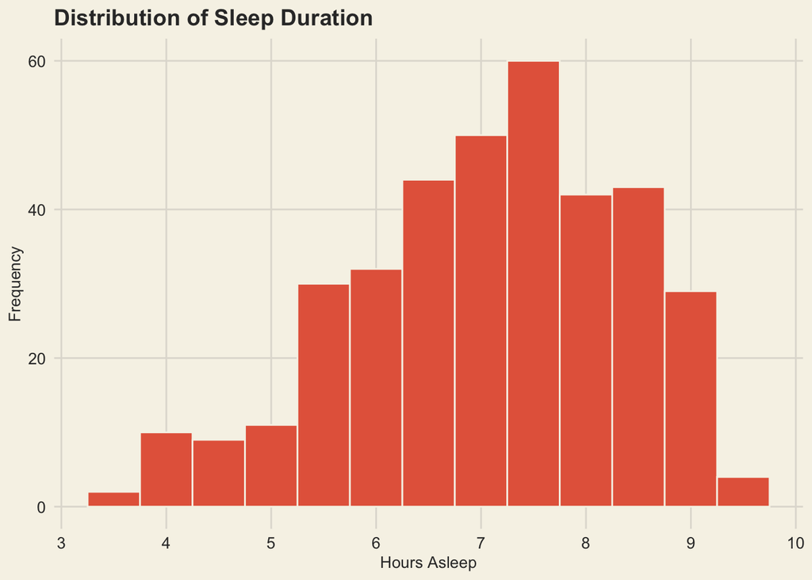

```r
# Histogram
ggplot(merged, aes(x = total_minutes_asleep / 60)) +
  geom_histogram(
    binwidth = 0.5,
    fill = "#e5664a",
    color = "#f6f3e8"
  ) +
  scale_x_continuous(
    limits = c(3, 10),
    breaks = seq(3, 10, by = 1),
    expand = c(0.01, 0)
  ) +
  labs(
    title = "Distribution of Sleep Duration",
    x = "Hours Asleep",
    y = "Frequency"
  ) +
  theme_minimal() +
  theme(
    plot.background  = element_rect(fill = "#f6f3e8", color = NA),
    panel.background = element_rect(fill = "#f6f3e8", color = NA),

    plot.title = element_text(
      face = "bold",
      size = 14,
      color = "#343434"
    ),
    axis.title = element_text(
      size = 10,
      color = "#343434"
    ),
    axis.text = element_text(
      size = 10,
      color = "#343434"
    ),

    panel.grid.major = element_line(color = "#e0ddd5"),
    panel.grid.minor = element_blank()
  )
```

- This suggests average sleep health is okay but not optimal—users get close to the recommended range, but not consistently.
- There is a clear left tail around 3.5–5.5 hours, meaning: Some users frequently experience short sleep durations

```r
# Preparing data
intensity_breakdown <- merged %>%
  select(lightly_active_minutes, fairly_active_minutes, very_active_minutes) %>%
  summarise(
    light = mean(lightly_active_minutes, na.rm = TRUE),
    fair = mean(fairly_active_minutes, na.rm = TRUE),
    very = mean(very_active_minutes, na.rm = TRUE)
  ) %>%
  pivot_longer(cols = everything(), names_to = "intensity", values_to = "minutes")
```

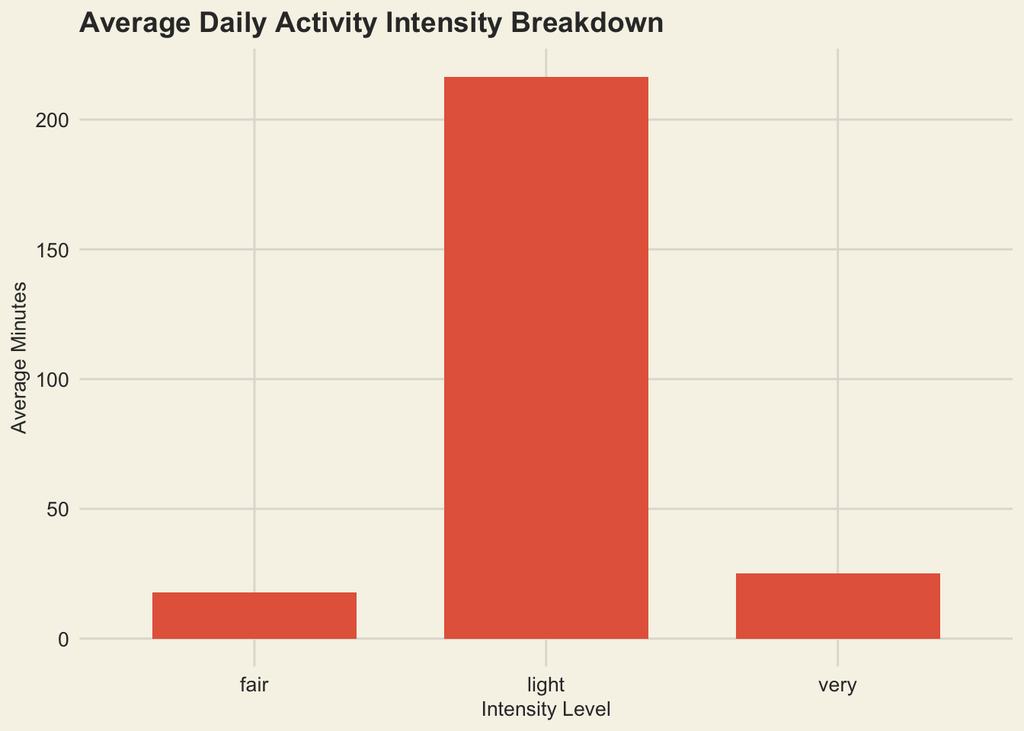

```r
# Bar Graph
ggplot(intensity_breakdown, aes(x = intensity, y = minutes)) +
  geom_col(fill = "#e5664a", width = 0.7) +
  labs(
    title = "Average Daily Activity Intensity Breakdown",
    x = "Intensity Level",
    y = "Average Minutes"
  ) +
  theme_minimal() +
  theme(
    plot.background  = element_rect(fill = "#f6f3e8", color = NA),
    panel.background = element_rect(fill = "#f6f3e8", color = NA),

    plot.title = element_text(
      face = "bold",
      size = 14,
      color = "#343434"
    ),
    axis.title = element_text(
      size = 10,
      color = "#343434"
    ),
    axis.text = element_text(
      size = 10,
      color = "#343434"
    ),

    panel.grid.major = element_line(color = "#e0ddd5"),
    panel.grid.minor = element_blank()
  )
```

- This confirms that users prefer low-effort, lifestyle-based movement
- Users are not engaging in regular, structured moderate exercise.

# Recommendations for Bellabeat

**1. Promote Consistency Over High Performance:** Users are inconsistent with steps and light activity.Bellabeat can position Leaf as a daily habit-builder.

**2. Introduce Sedentary Interrupt Features:** Users sit ≈ 12 hours/day.Promote posture alerts, stretch reminders, “stand and reset” nudges.

**3. Support Sleep Routine Stabilization:** Sleep compliance is only 46%. Create a “Leaf Sleep Guide”: bedtime reminders, screen-time reduction cues.

**4. Design Weekend + Monday Motivation Campaigns:** Steps peak on Saturday and Monday. Use these days to push challenges, streaks, and motivational prompts.

**5. Highlight Low-Impact Wellness:** Most users do NOT engage in moderate or intense exercise. Bellabeat should emphasize walking, light movement, and lifestyle activity.

**Cons**

- Fitbit users may not represent Bellabeat’s core audience
- The sample size is small and self-selected
- The data is old (2016)
- We can see correlation, not causation

# Conclusion

The data suggests Bellabeat’s biggest opportunity is not intense workouts, but helping users reduce prolonged sitting, build light daily movement, and improve sleep consistency — especially with only 46% of days meeting sleep goals.

However, these findings are based on limited and short-term data, and don’t capture factors like stress, work schedules, or long-term habit changes. To make stronger product decisions, Bellabeat should collect deeper, longer-term behavioral data and explore why users struggle with sleep and consistency — not just how often.

This creates a clear next step: use Leaf not just to track behavior, but to learn what truly drives it.